# Validation of Forecasts with SeaVal

This sheet gives a short introduction how to use the `R`-package 'SeaVal' for seasonal validation. This package is currently developed at NR and made available via Github. The package will provide a toolkit to evaluate predictions issued by ICPAC. `SeaVal` relies on R data tables (available with the `R` package `data.table`). Data tables are more flexible and memory efficient data frames, and simplify many operations that are frequently required when working with weather- and climate data. An introduction to data tables can be found here: https://cran.r-project.org/web/packages/data.table/vignettes/datatable-intro.html `SeaVal` will allow to convert the output of forecast models and observations generated at ICPAC into data tables. Moreover it will contain functionality for generating a variety of diagnostic plots, and provide various tools for forecast evaluation.

## Setting up `SeaVal`

In order to get started with the package you first need to install the packages `devtools` (if you don't have it already), which allows installing packages from Github directly:

```r
install.packages('devtools')
```

Now you should be able to install the `SeaVal`-package like this:

```r
devtools::install_github('SeasonalForecastingEngine/SeaVal')
```

This line should not only install the `SeaVal` package, but also all packages it depends on. This may take a while, especially if you haven't installed some of the larger packages that we utilize, such as `data.table` or `ggplot2`. Also, it is possible that you'll get a message like this:

```
These packages have more recent versions available.
It is recommended to update all of them.
Which would you like to update?

1: All
2: CRAN packages only
3: None
...
```

In that case just type '1' for all.

If this completes without an error, the setup is complete and you're good to go. From here on out, all you have to do is load `SeaVal`:

```r
library(SeaVal)
```

This imports all functionality of the SeaVal package. It also imports the package `data.table`, so you don't need to put a separate `library(data.table)` in order to have data table syntax and functionality available.

## `data.table` syntax

Here we show with some examples how to perform basic operations on data tables. A short but comprehensive introduction to `data.table`s syntax can be found here: https://cran.r-project.org/web/packages/data.table/vignettes/datatable-intro.html. The `SeaVal` package comes with a few example data sets, for example monthly mean precipitation over the GHA region for the OND season provided by CHIRPS:

```r
data("chirps_monthly")
print(chirps_monthly)
```

```
##          lon   lat      prec month year terc_cat
##      1: 22.0 -12.0 1.9301587    10 1981       -1
##      2: 22.0 -11.5 2.1351602    10 1981       -1
##      3: 22.0 -11.0 2.7692883    10 1981       -1
##      4: 22.0 -10.5 3.9201619    10 1981        0
##      5: 22.0 -10.0 4.8720656    10 1981        1
##     ---
## 418076: 51.5  21.0 0.2404348    12 2020       -1
## 418077: 51.5  21.5 0.2184058    12 2020       -1
## 418078: 51.5  22.0 0.2053623    12 2020       -1
## 418079: 51.5  22.5 0.1615942    12 2020       -1
## 418080: 51.5  23.0 0.1387682    12 2020       -1
```

We can look at a short description of the dataset like this:

```r
?chirps_monthly
```

We'll now go over a few basic commands for handling this sort of data. `chirps_monthly` is a data_table, which is an enhanced data frame. The most fundamental operations include subsetting, performing calculations on columns and aggregation or grouping for calculations. Examples for subsetting are

```r
chirps_monthly[month == 10] # extract the data for October
```

```
##          lon   lat        prec month year terc_cat
##      1: 22.0 -12.0 1.930158724    10 1981       -1
##      2: 22.0 -11.5 2.135160243    10 1981       -1
##      3: 22.0 -11.0 2.769288266    10 1981       -1
##      4: 22.0 -10.5 3.920161870    10 1981        0
##      5: 22.0 -10.0 4.872065602    10 1981        1
##     ---
## 139356: 51.5  21.0 0.033333333    10 2020       -1
## 139357: 51.5  21.5 0.033333333    10 2020        0
## 139358: 51.5  22.0 0.032608688    10 2020       -1
## 139359: 51.5  22.5 0.001594238    10 2020       -1
## 139360: 51.5  23.0 0.000000000    10 2020       -1
```

```r
chirps_monthly[year %between% c(1990,1999)] # extract the data for 1990 - 1999
```

```
##          lon   lat      prec month year terc_cat
##      1: 22.0 -12.0 3.1261905    10 1990        1
##      2: 22.0 -11.5 3.5520651    10 1990        1
##      3: 22.0 -11.0 3.9256340    10 1990        1
##      4: 22.0 -10.5 4.4879379    10 1990        1
##      5: 22.0 -10.0 4.4143639    10 1990        0
##     ---
## 104516: 51.5  21.0 0.2565218    12 1999        0
## 104517: 51.5  21.5 0.2427537    12 1999        1
## 104518: 51.5  22.0 0.2171015    12 1999        1
## 104519: 51.5  22.5 0.2000000    12 1999        1
## 104520: 51.5  23.0 0.1981884    12 1999        1
```

```r
chirps_monthly[1000:2000] # extract rows 1000 - 2000
```

```
##       lon  lat       prec month year terc_cat
##    1:  29 -9.5 1.74899961    10 1981        0
##    2:  29 -9.0 1.44546648    10 1981       -1
##    3:  29 -8.5 1.45933371    10 1981       -1
##    4:  29 -8.0 1.52153314    10 1981       -1
##    5:  29 -7.5 1.35046587    10 1981       -1
##   ---
##  997:  36 -8.5 0.49439943    10 1981        0
##  998:  36 -8.0 0.31293185    10 1981        0
##  999:  36 -7.5 0.06879925    10 1981       -1
## 1000:  36 -7.0 0.01446661    10 1981       -1
## 1001:  36 -6.5 0.04019988    10 1981        0
```

```r
chirps_monthly[month == 10][lon > 30][terc_cat == 0] #chained subsetting: get all October values at locations with longitude >30 that had normal rainfall (terc_cat == 0)
```

```
##         lon   lat       prec month year terc_cat
##     1: 30.5 -10.5 0.67720063    10 1981        0
##     2: 30.5 -10.0 0.78526832    10 1981        0
##     3: 30.5  -9.5 1.03640187    10 1981        0
##     4: 30.5  -9.0 0.96939957    10 1981        0
##     5: 30.5  -8.5 0.52219994    10 1981        0
##    ---
## 32909: 51.0  20.0 0.06666667    10 2020        0
## 32910: 51.0  21.5 0.03333333    10 2020        0
## 32911: 51.5  19.5 0.06666667    10 2020        0
## 32912: 51.5  20.0 0.06666667    10 2020        0
## 32913: 51.5  21.5 0.03333333    10 2020        0
```

```r
chirps_monthly[month == 10 & lon > 30 & terc_cat == 0] # different syntax, same effect.
```

```
##         lon   lat       prec month year terc_cat
##     1: 30.5 -10.5 0.67720063    10 1981        0
##     2: 30.5 -10.0 0.78526832    10 1981        0
##     3: 30.5  -9.5 1.03640187    10 1981        0
##     4: 30.5  -9.0 0.96939957    10 1981        0
##     5: 30.5  -8.5 0.52219994    10 1981        0
##    ---
## 32909: 51.0  20.0 0.06666667    10 2020        0
## 32910: 51.0  21.5 0.03333333    10 2020        0
## 32911: 51.5  19.5 0.06666667    10 2020        0
## 32912: 51.5  20.0 0.06666667    10 2020        0
## 32913: 51.5  21.5 0.03333333    10 2020        0
```

We can subset either by logical expressions or by row indices (third example above). Subsetting always returns a data table, e.g. `chirps_monthly[1]` returns a one-row data table containing the first row of `chirps_monthly`.

Next, let's look at examples for operations on columns:

```r
chirps_monthly[,mean(prec)] # get the mean precipitation (over all locations, months, years)
```

```
## [1] 1.995215
```

```r
chirps_monthly[,mean_prec := mean(prec)] # create a new column in the data table containing the mean
chirps_monthly[,prec := 30*prec] # transform precipitation from unit mm/day to mm (per month)
```

Note in all cases the ',' after '[' which tells data table that you're doing an operation rather than trying to subset. We can also put things together and subset and operate simultaneously:

```r
chirps_monthly[month == 10 , mean(prec)] # get the mean precipitation for October (over all locations, years)
```

```
## [1] 66.30285
```

(Note that the mean is much larger now because we changed units above...)

Finally, we can perform operations over aggregated groups:

```r
dt_new = chirps_monthly[, mean(prec),by = .(lon,lat,month)]
print(dt_new)
```

```
##         lon   lat month         V1
##     1: 22.0 -12.0    10  84.507765
##     2: 22.0 -11.5    10  92.716755
##     3: 22.0 -11.0    10 104.027108
##     4: 22.0 -10.5    10 116.425850
##     5: 22.0 -10.0    10 128.969907
##    ---
## 10448: 51.5  21.0    12   7.679457
## 10449: 51.5  21.5    12   7.247609
## 10450: 51.5  22.0    12   6.454131
## 10451: 51.5  22.5    12   5.612391
## 10452: 51.5  23.0    12   5.103941
```

Here, the 'by' command (after the second comma) tells data table to perform the operation (`mean`) for each instance of `lon`, `lat`, and `month` separately. As a result, the mean is taken only over all years and we obtain the monthly local climatology. As we can see, the output is a data table containing all columns in `by` and a column named `V1` containing the output of the operation. That's of course a bit impractical. But it's easy to rename columns:

```r
setnames(dt_new,'V1','clim') # take the data table from above and rename column 'V1' into 'clim'
```

It's also possible to name the column direcly while `dt_new` is created, like this:

```r
dt_new = chirps_monthly[,.(clim = mean(prec)),by = .(lon,lat,month)] # same as above, but with simultaneously setting the name of the new column
```

This can again be combined with subsetting:

```r
dt_new = chirps_monthly[year %in% 1990:2020, .(clim = mean(prec)), by = .(lon,lat,month)] # same as above, but with additional subsetting: computes climatology based on the years 1990-2020 only.
```

In the examples above we create a new data table containing the climatology. If we instead want to add the climatology as a new column to `chirps_monthly` directly, we can again use the `:=` operator:

```r
chirps_monthly[,clim := mean(prec), by = .(lon,lat,month)] # add the climatology column directly into chirps_monthly.
```

This showcases some of the main functionalities and syntax of the `data.table` package. As mentioned above, it is strongly recommended to have a look at https://cran.r-project.org/web/packages/data.table/vignettes/datatable-intro.html, which introduces many more commands and properly explains the logic underlying `data.table`s syntax. We'll finish this section by an example where we compute the MSE for raw ecmwf forecasts:

```r
data("chirps_monthly") # reload data to reverse the changes made in the examples above.
data("ecmwf_monthly") # get example hindcasts from ecmwf

print(ecmwf_monthly)
```

```
##         lon  lat year month         prec member below normal above
##      1:  22 13.0 1993    10 0.0118023199      1  0.60   0.20  0.20
##      2:  22 13.0 1993    10 0.0257743523      2  0.60   0.20  0.20
##      3:  22 13.0 1993    10 0.0008075972      3  0.60   0.20  0.20
##      4:  22 13.0 1993    10 0.1190863216      4  0.60   0.20  0.20
##      5:  22 13.0 1993    10 0.0002728474      5  0.60   0.20  0.20
##     ---
## 868556:  51 11.5 2020    12 0.8410410288      1  0.36   0.28  0.36
## 868557:  51 11.5 2020    12 0.7719732821      2  0.36   0.28  0.36
## 868558:  51 11.5 2020    12 1.4691380784      3  0.36   0.28  0.36
## 868559:  51 11.5 2020    12 1.2364573109      4  0.36   0.28  0.36
## 868560:  51 11.5 2020    12 1.2289135981      5  0.36   0.28  0.36
```

```r
# merge observations and predictions into a single data table:
setnames(chirps_monthly,'prec','obs') # rename the 'prec' column in the observation data table to 'obs' in order to avoid name clashes since the column in ecmwf_monthly containing the predictions for precip is also named 'prec'
dt = merge(ecmwf_monthly,chirps_monthly,
           by = c('lon','lat','year','month')) # merge the data.

print(dt)
```

```
##         lon  lat year month         prec member below normal above       obs terc_cat
##      1:  22 13.0 1993    10 0.0118023199      1  0.60   0.20  0.20 0.3490475        0
##      2:  22 13.0 1993    10 0.0257743523      2  0.60   0.20  0.20 0.3490475        0
##      3:  22 13.0 1993    10 0.0008075972      3  0.60   0.20  0.20 0.3490475        0
##      4:  22 13.0 1993    10 0.1190863216      4  0.60   0.20  0.20 0.3490475        0
##      5:  22 13.0 1993    10 0.0002728474      5  0.60   0.20  0.20 0.3490475        0
##     ---
## 868556:  51 11.5 2020    12 0.8410410288      1  0.36   0.28  0.36 0.5262209        0
## 868557:  51 11.5 2020    12 0.7719732821      2  0.36   0.28  0.36 0.5262209        0
## 868558:  51 11.5 2020    12 1.4691380784      3  0.36   0.28  0.36 0.5262209        0
## 868559:  51 11.5 2020    12 1.2364573109      4  0.36   0.28  0.36 0.5262209        0
## 868560:  51 11.5 2020    12 1.2289135981      5  0.36   0.28  0.36 0.5262209        0
```

```r
dt[,ens_mean := mean(prec),by = .(lon,lat,year,month)] # get the ensemble mean, essentially group by all other dimension variables

mse_dt = dt[,.(mse = mean((prec-obs)^2)), by = .(lon,lat,month)] # create a new data.table containing the mse by location and month

print(mse_dt)
```

```
##        lon  lat month          mse
##    1: 22.0 13.0    10 7.263275e-01
##    2: 22.0 13.0    11 2.330523e-03
##    3: 22.0 13.0    12 4.717186e-05
##    4: 22.5 12.5    10 1.100971e+00
##    5: 22.5 12.5    11 8.114504e-03
##   ---
## 6200: 51.0 11.0    11 2.520367e+00
## 6201: 51.0 11.0    12 1.086045e+00
## 6202: 51.0 11.5    10 1.304131e+00
## 6203: 51.0 11.5    11 3.431530e+00
## 6204: 51.0 11.5    12 1.362873e+00
```

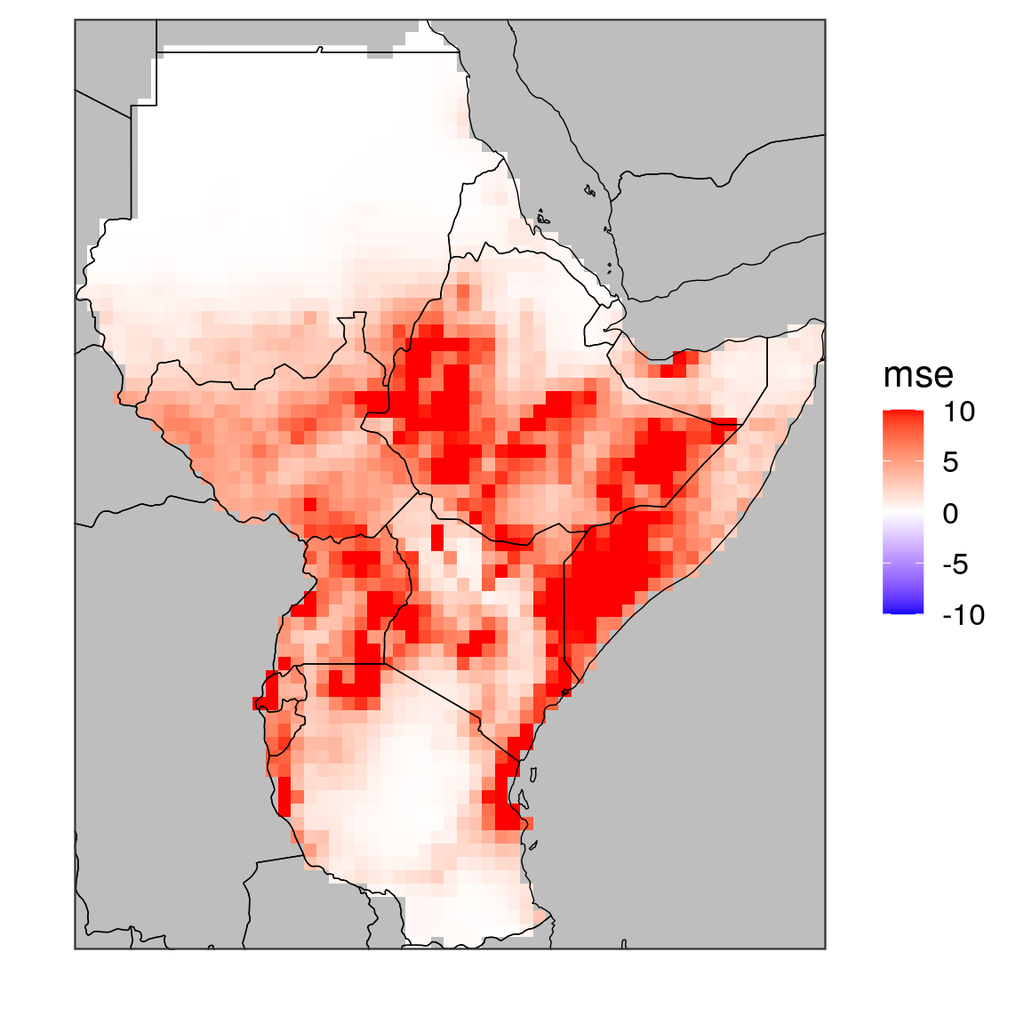

```r
ggplot_dt(mse_dt[month == 10],'mse',rr = c(-10,10) ) # plot mse for October
```

The function `ggplot_dt` is used to create spatial plots from data stored in data tables. In the next section we will showcase how this function works and how the plots can be manipulated.

## Spatial plotting

The function `ggplot_dt` takes a data table containing two columns named `lon` and `lat` that should specify a regular longitude-latitude grid, as well as some data to use for coloring the map. An easy example is the following

```r
dt = chirps_monthly[year == 2020 & month == 10] # reduce the observed precipitation data to a single time slice, namely October 2020
print(dt) # recall that we renamed the column 'prec' into 'obs'
```

```
##        lon   lat         obs month year terc_cat
##    1: 22.0 -12.0 2.981750252    10 2020        0
##    2: 22.0 -11.5 3.382063644    10 2020        0
##    3: 22.0 -11.0 3.250394658    10 2020        0
##    4: 22.0 -10.5 3.065396443    10 2020       -1
##    5: 22.0 -10.0 3.416906726    10 2020       -1
##   ---
## 3480: 51.5  21.0 0.033333333    10 2020       -1
## 3481: 51.5  21.5 0.033333333    10 2020        0
## 3482: 51.5  22.0 0.032608688    10 2020       -1
## 3483: 51.5  22.5 0.001594238    10 2020       -1
## 3484: 51.5  23.0 0.000000000    10 2020       -1
```

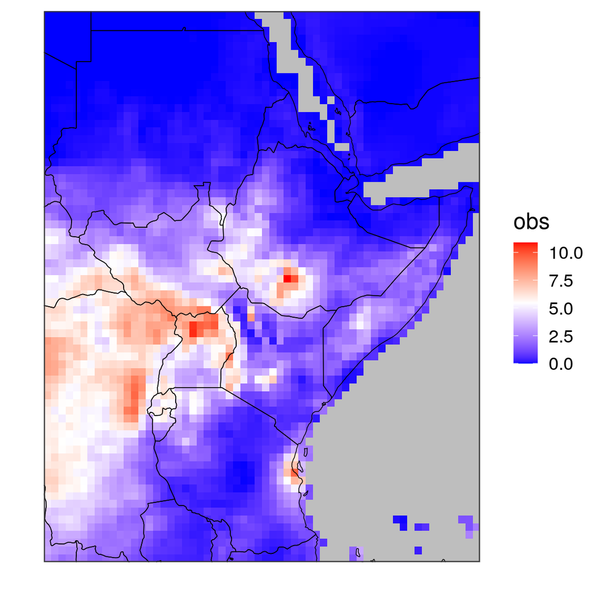

```r
ggplot_dt(dt,'obs')
```

As we can see, the color scale here makes no sense (blue meaning no precipitation) and we'll talk about that in a second. But let's start at the base functionality. `ggplot_dt` requires two arguments, the first one being a data table containing the data, and the second one is the name of the column that contains the data you want to plot. This defaults to the third column in the data table (often your data table will start with lon, lat, and the third column is what you want to plot). So in the example above, `ggplot_dt(dt)` would have led to the same result, because `'obs'` is the third column in `dt`. The plotting window is determined by the data. If you have data covering the entire earth, the entire earth would be plotted. As a consequence, we can restrict the plotted region by subsetting the data table:

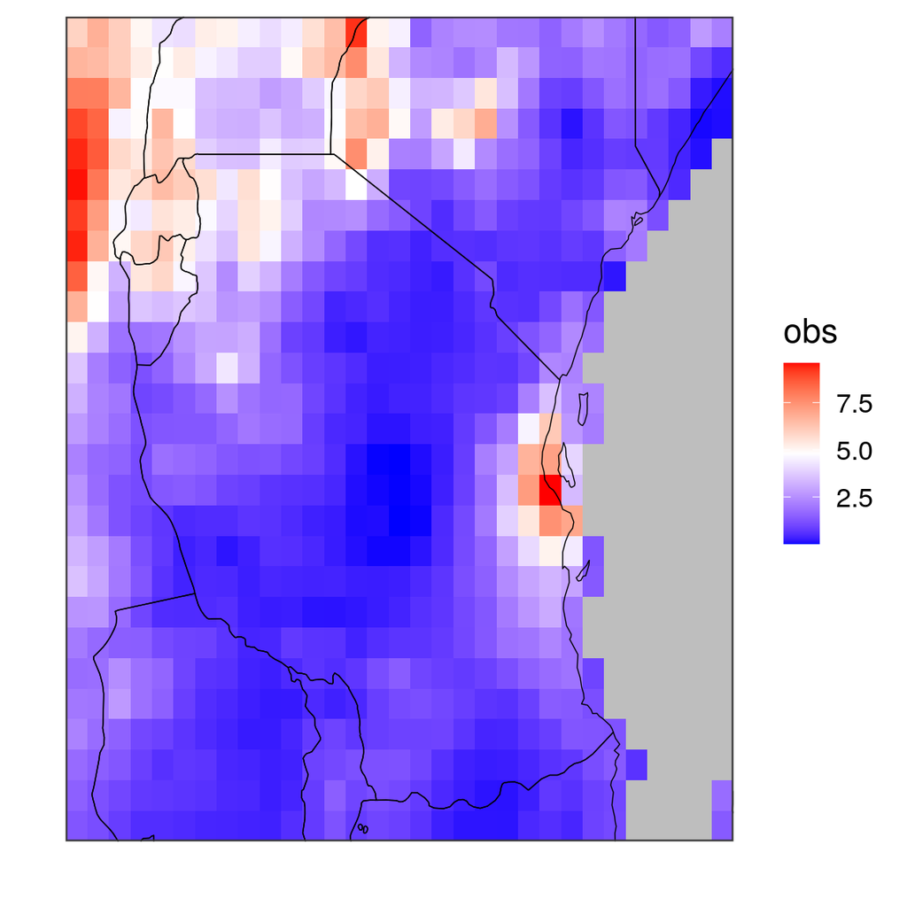

```r
dt_sub  = dt[lon %between% c(28,43) & lat %between% c(-12,1)] # a region containing Tanzania
ggplot_dt(dt_sub)
```

The function has further optional arguments (also recall that you can access the function documentation summarizing all of this by typing `?ggplot_dt`):

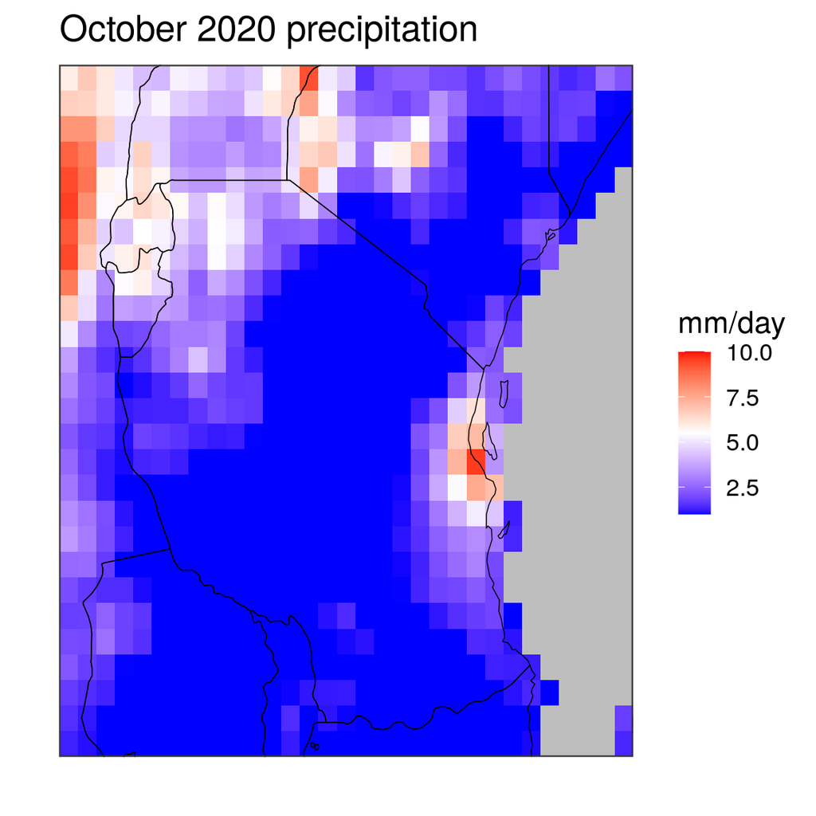

```r
ggplot_dt(dt_sub,'obs',
          mn = 'October 2020 precipitation', # add a title to the plot
          rr = c(1,10), # fix the limits of the color scale
          name = 'mm/day') # change the legend label
```

In this example we set the lower limit of the color scale to 1 and the upper limit to 10. Note that the plot truncates the data at the ends of the color scale, so every pixel with precipitation of below 1mm/day is now shown in the same blue color. Setting the range of the color scale is particularly useful to force symmetry around 0, e.g. when plotting correlations or anomalies:

```r
chirps_monthly[,clim := mean(obs), by = .(lon,lat,month)] # add a climatology column
chirps_monthly[,ano := obs - clim] # add anomaly as another column
print(chirps_monthly)
```

```
##          lon   lat       obs month year terc_cat      clim          ano
##      1: 22.0 -12.0 1.9301587    10 1981       -1 2.8169255 -0.886766778
##      2: 22.0 -11.5 2.1351602    10 1981       -1 3.0905585 -0.955398264
##      3: 22.0 -11.0 2.7692883    10 1981       -1 3.4675703 -0.698281996
##      4: 22.0 -10.5 3.9201619    10 1981        0 3.8808617  0.039300191
##      5: 22.0 -10.0 4.8720656    10 1981        1 4.2989969  0.573068714
##     ---
## 418076: 51.5  21.0 0.2404348    12 2020       -1 0.2559819 -0.015547112
## 418077: 51.5  21.5 0.2184058    12 2020       -1 0.2415870 -0.023181188
## 418078: 51.5  22.0 0.2053623    12 2020       -1 0.2151377 -0.009775418
## 418079: 51.5  22.5 0.1615942    12 2020       -1 0.1870797 -0.025485473
## 418080: 51.5  23.0 0.1387682    12 2020       -1 0.1701314 -0.031363167
```

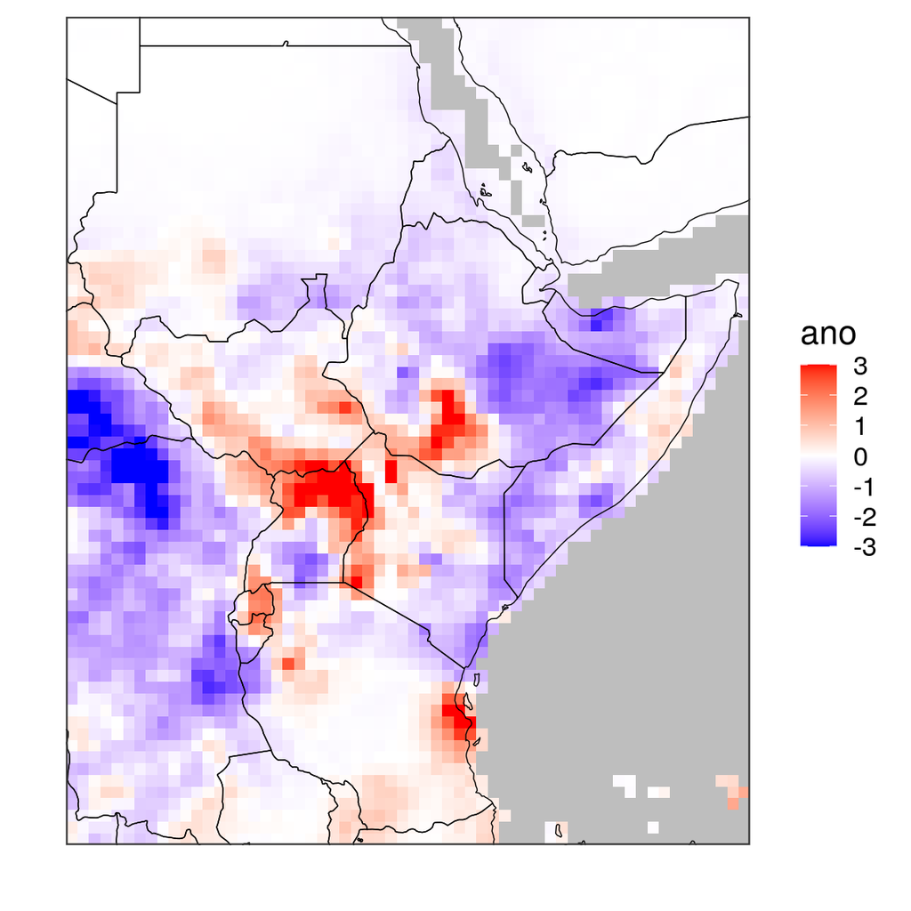

```r
ggplot_dt(chirps_monthly[month == 10 & year == 2020], 'ano', rr = c(-3,3))
```

Now, in this plot positive rainfall anomalies are shown red while negative anomalies are blue, which is very counterintuitive. The function allows us to specify the three used colors by name with the arguments `low`,`mid`, and `high`. So here's an anomaly plot looking a bit nicer:

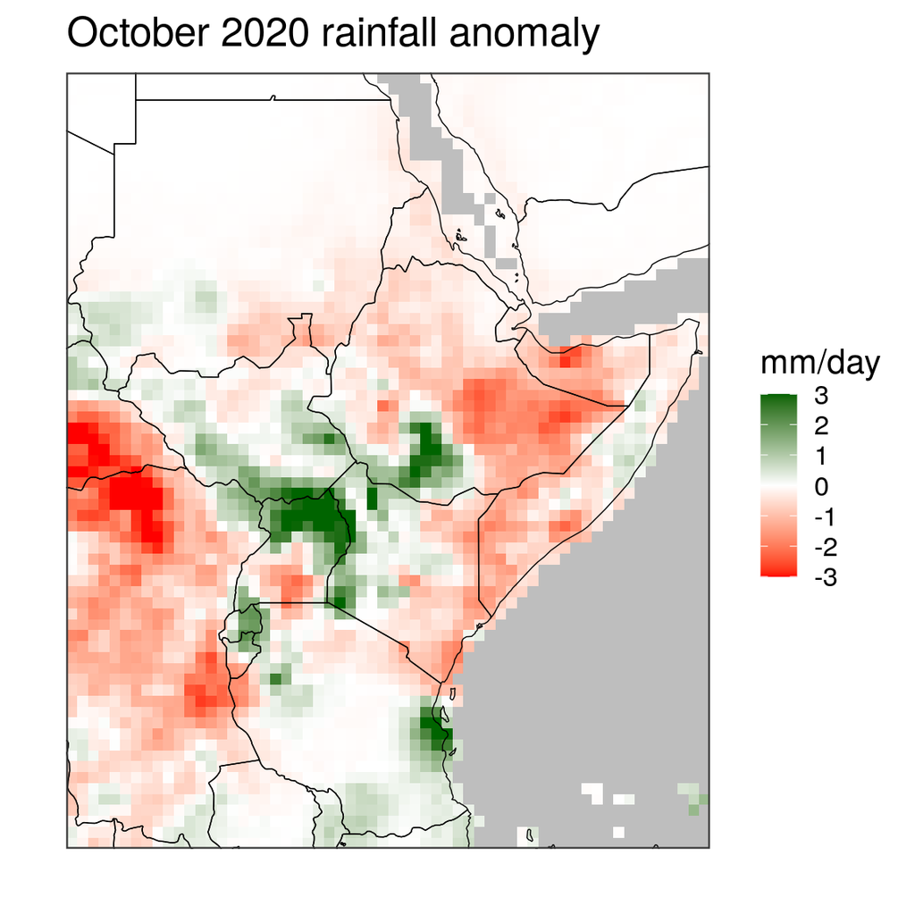

```r
ggplot_dt(chirps_monthly[month == 10 & year == 2020], 'ano',
          mn = 'October 2020 rainfall anomaly',
          rr = c(-3,3),
          low = 'red', mid = 'white', high = 'darkgreen',
          name = 'mm/day')
```

Note that we set the range argument to `c(-3,3)`. Fixing the range makes mostly sense when the range is known (e.g. for correlation plots), or when you want to compare several plots (e.g. for comparing mean square error of different NWP models, all plots should have the same range). If we leave the range argument `rr` free, the range is determined from the data. However, when we do this for our anomaly plot this has an undesired sideeffect:

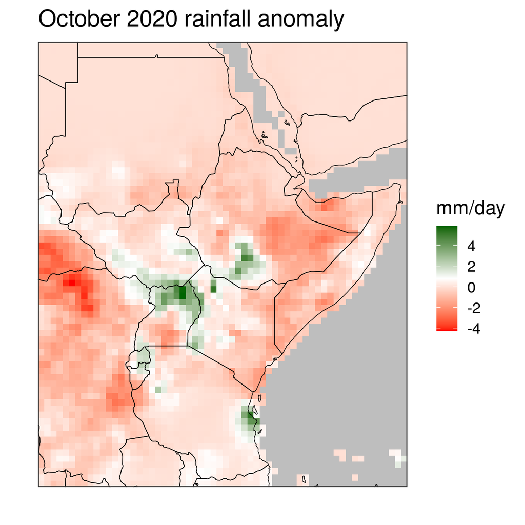

```r
ggplot_dt(chirps_monthly[month == 10 & year == 2020], 'ano',
          mn = 'October 2020 rainfall anomaly',
          low = 'red', mid = 'white', high = 'darkgreen',
          name = 'mm/day')
```

The color scale is no longer centered (white) at 0, but in the center of the (now asymetric) range. As a consequence, all gridpoints with anomaly 0 are shown in a light red. To fix this we can use the `midpoint` argument:

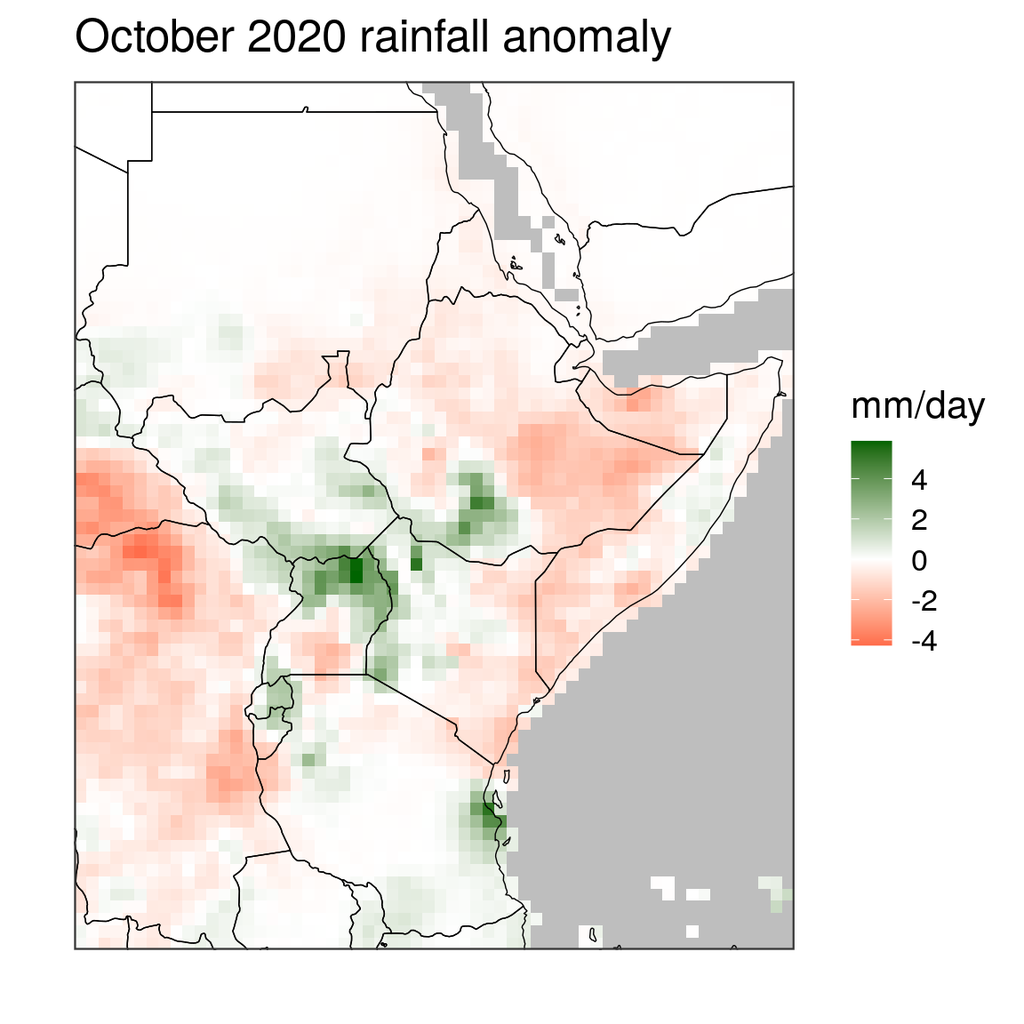

```r
ggplot_dt(chirps_monthly[month == 10 & year == 2020], 'ano',
          mn = 'October 2020 rainfall anomaly',
          low = 'red', mid = 'white', high = 'darkgreen',
          midpoint = 0,
          name = 'mm/day')
```

Another, maybe surprising, use for the `midpoint` argument is that we can generate plots with a colorscale with only two colors. For example, going back to plotting the observed rainfall we can do the following:

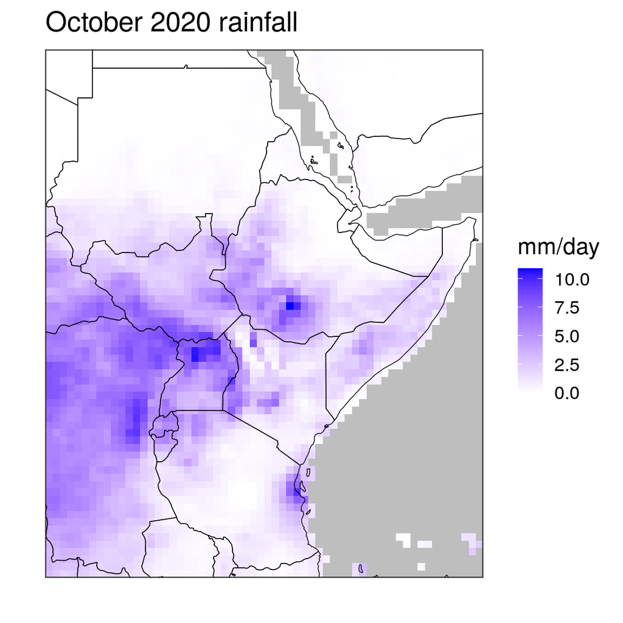

```r
ggplot_dt(chirps_monthly[month == 10 & year == 2020], 'obs',
          mn = 'October 2020 rainfall',
          mid = 'white', high = 'blue',
          midpoint = 0,
          name = 'mm/day')
```

What happens here is that we set the midpoint to 0, which is the minimum of our data (since observed rainfall is never below 0). Consequently the second half of the colorscale extends below 0 and does not affect the plot.

Finally,the function allows to discretize the color scale. To this end we need to set the argument `discrete_cs` to `TRUE`. We can then control the breaks of the discrete colorscale by either of the documents `binwidth`, `n.breaks`, or `breaks` (the latter takes a vector containing all breakpoints). To revisit the anomaly plot from above:

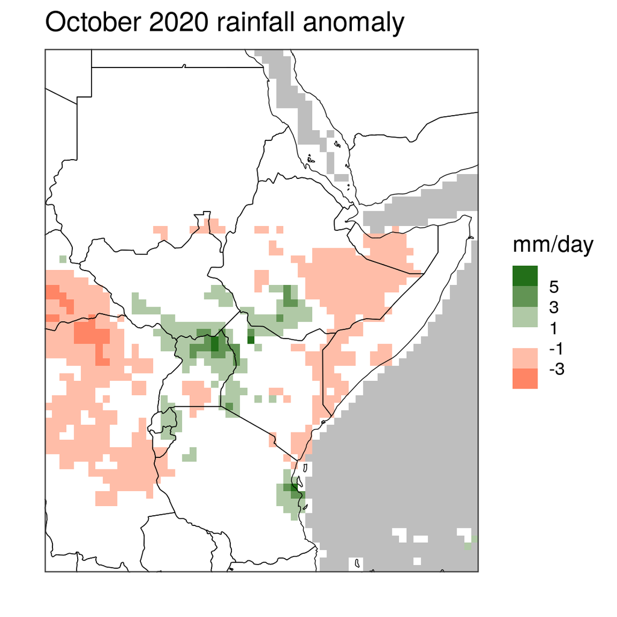

```r
ggplot_dt(chirps_monthly[month == 10 & year == 2020], 'ano',
          mn = 'October 2020 rainfall anomaly',
          discrete_cs = TRUE, binwidth = 2,
          low = 'red', mid = 'white', high = 'darkgreen',
          midpoint = 0,
          name = 'mm/day')
```

One final remark: Often you will deal with data tables that contain spatio-temporal data. It is then important to subselect the particular timeslice you want to plot before plotting (as we did above when we plotted October 2020). The function `ggplot_dt` by default tries to select the first timeslice of tempo-spatial data. This is often not what you want (which is why you should subselect first), but it's frequently handy for quick data diagnostics, which is the reason for this default behavior. Here an example:

```r
print(chirps_monthly) # a data table with multiple months and years and locations, so spatio-temporal data
```

```
##          lon   lat       obs month year terc_cat      clim          ano
##      1: 22.0 -12.0 1.9301587    10 1981       -1 2.8169255 -0.886766778
##      2: 22.0 -11.5 2.1351602    10 1981       -1 3.0905585 -0.955398264
##      3: 22.0 -11.0 2.7692883    10 1981       -1 3.4675703 -0.698281996
##      4: 22.0 -10.5 3.9201619    10 1981        0 3.8808617  0.039300191
##      5: 22.0 -10.0 4.8720656    10 1981        1 4.2989969  0.573068714
##     ---
## 418076: 51.5  21.0 0.2404348    12 2020       -1 0.2559819 -0.015547112
## 418077: 51.5  21.5 0.2184058    12 2020       -1 0.2415870 -0.023181188
## 418078: 51.5  22.0 0.2053623    12 2020       -1 0.2151377 -0.009775418
## 418079: 51.5  22.5 0.1615942    12 2020       -1 0.1870797 -0.025485473
## 418080: 51.5  23.0 0.1387682    12 2020       -1 0.1701314 -0.031363167
```

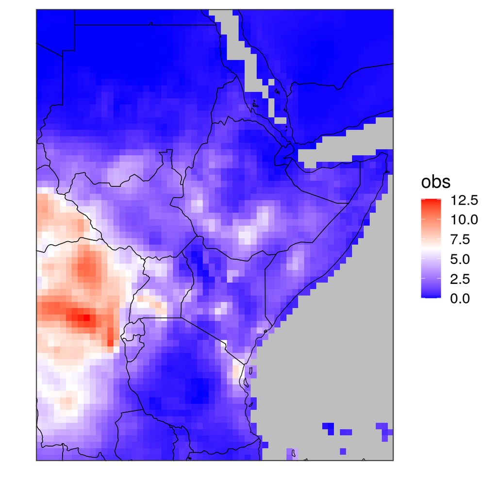

```r
ggplot_dt(chirps_monthly) # generates a plot of the precipitation of October 1981 (first timeslice), for a first quick impression how your data looks
```

## Plotting values for selected countries

We have already seen an option above how to focus the plot on a particular country: by manually subsetting the data to a rectangle of longitudes and latitudes containing that specific country. This is of course quite tedious, and to make our lives easier we can use the `restrict_to_country`-function that takes a data table and a country name, and subsets the data table to only contain gridpoints in the specified country. Currently, the function accepts the following country names: Burundi, Eritrea, Ethiopia, Kenya, Rwanda, Somalia, South Sudan, Sudan, Tansania, Uganda.

```r
dt_new = restrict_to_country(chirps_monthly[month == 10 & year == 2020],'Kenya')
print(dt_new)
```

```
##       lon  lat       obs month year terc_cat     clim        ano
##   1: 34.0 -1.0 4.9593979    10 2020        1 2.964475  1.9949232
##   2: 34.0 -0.5 4.7645891    10 2020        1 3.639693  1.1248956
##   3: 34.0  0.0 4.6154697    10 2020        1 4.284345  0.3311242
##   4: 34.5 -1.0 7.5550100    10 2020        1 4.380272  3.1747380
##   5: 34.5 -0.5 6.4341863    10 2020        1 4.056996  2.3771907
##  ---
## 187: 41.0 -1.0 0.7533339    10 2020       -1 2.456691 -1.7033568
## 188: 41.0  3.0 1.1354665    10 2020        0 2.135546 -1.0000791
## 189: 41.0  3.5 1.5012010    10 2020        0 2.191273 -0.6900723
## 190: 41.0  4.0 1.8609376    10 2020        0 2.431412 -0.5704748
## 191: 41.5  3.5 1.3543324    10 2020        0 2.447758 -1.0934261
```

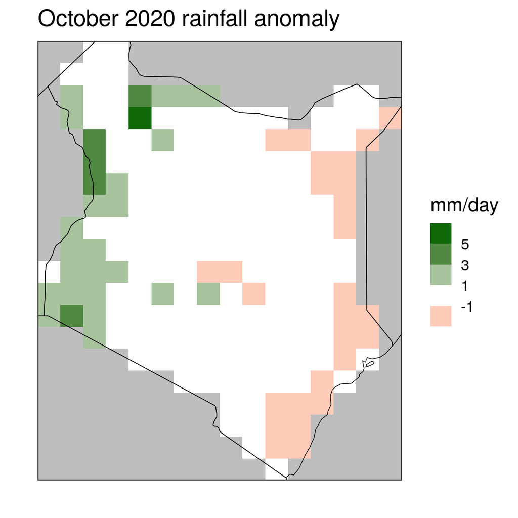

```r
ggplot_dt(dt_new, 'ano',
          mn = 'October 2020 rainfall anomaly',
          discrete_cs = TRUE, binwidth = 2,
          low = 'red', mid = 'white', high = 'darkgreen',
          midpoint = 0,
          name = 'mm/day')
```

As we can see, the function restricts the data to all gridcells for which the centerpoint lies within the specified country. This is useful, for example, for calculating mean scores for the specified country, but not optimal for plotting since everything past the border is censored. To this end, the `restrict_to_country` function has a `rectangle`-argument that should be set to `TRUE` for plotting:

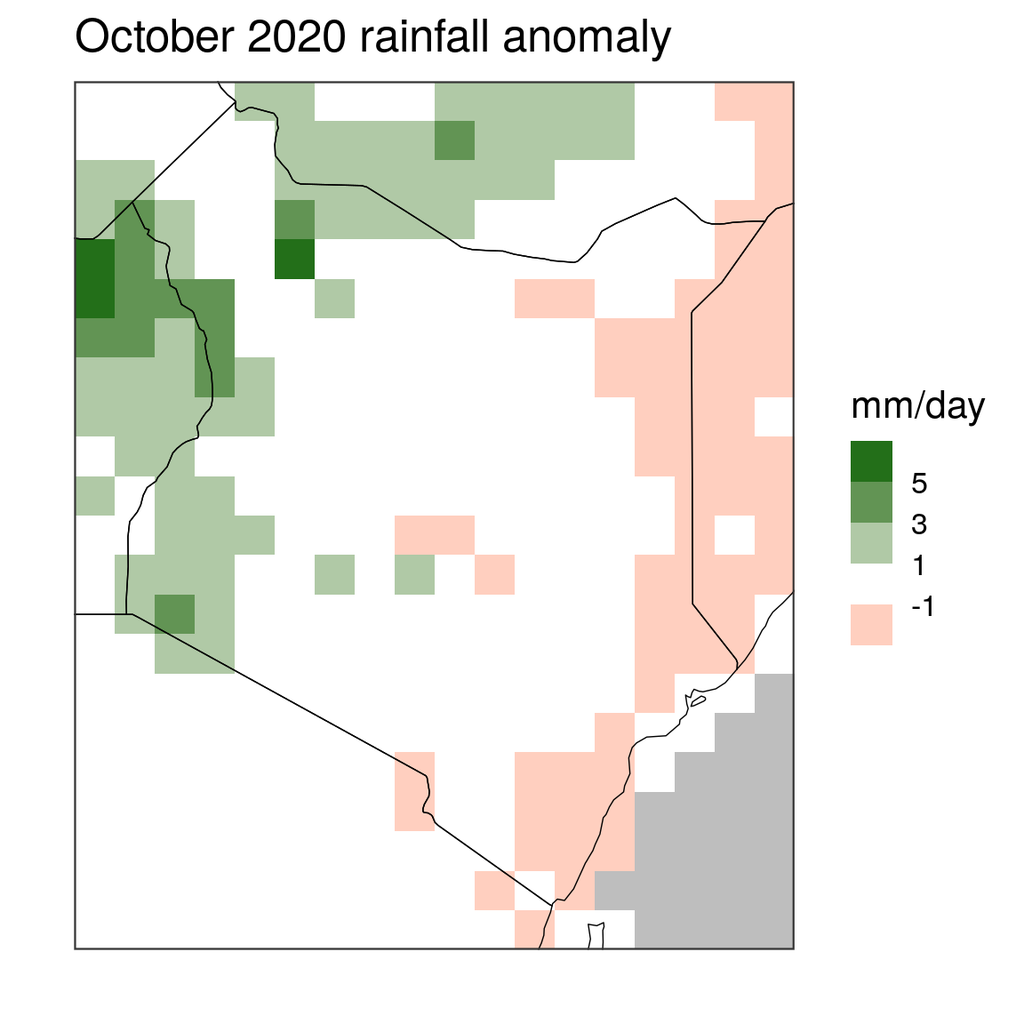

```r
dt_new = restrict_to_country(chirps_monthly[month == 10 & year == 2020],'Kenya', rectangle = TRUE)
ggplot_dt(dt_new, 'ano',
          mn = 'October 2020 rainfall anomaly',
          discrete_cs = TRUE, binwidth = 2,
          low = 'red', mid = 'white', high = 'darkgreen',
          midpoint = 0,
          name = 'mm/day')
```

Finally, let us note that you can pass multiple countries simultaneously to the function. Moreover, when you use `rectangle = TRUE`, you can specify a tolerance `tol` in order to widen the plotting window:

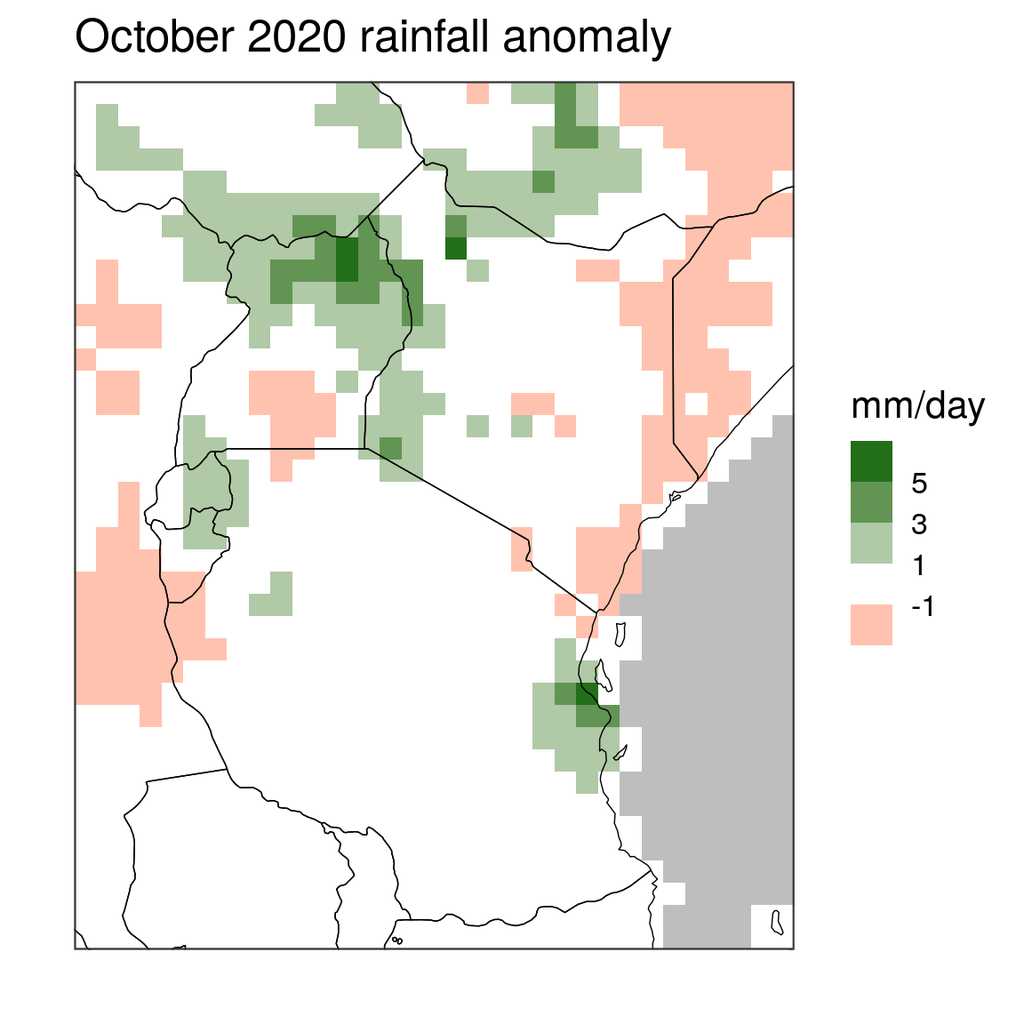

```r
dt_new = restrict_to_country(chirps_monthly[month == 10 & year == 2020],
                             c('Kenya','Tanzania'),
                             rectangle = TRUE,tol = 2)
ggplot_dt(dt_new, 'ano',
          mn = 'October 2020 rainfall anomaly',
          discrete_cs = TRUE, binwidth = 2,
          low = 'red', mid = 'white', high = 'darkgreen',
          midpoint = 0,
          name = 'mm/day')
```

## More plotting options

The function `ggplot_dt` is, as its name suggests, based on the package `ggplot2`. In `ggplot2`, plots are composed out of multiple layers, allowing for successive adding of layers. This can help us to generate highly customized plots. As an example, let's revisit the anomaly plot from above and add the location of Nairobi an Addis Abbaba to it:

```r
# get locations as data table:
loc = data.table(name = c('Addis Abbaba','Nairobi'),lon = c(38.77,36.84),lat = c(9,-1.28))
print(loc)
```

```
##            name   lon   lat
## 1: Addis Abbaba 38.77  9.00
## 2:      Nairobi 36.84 -1.28
```

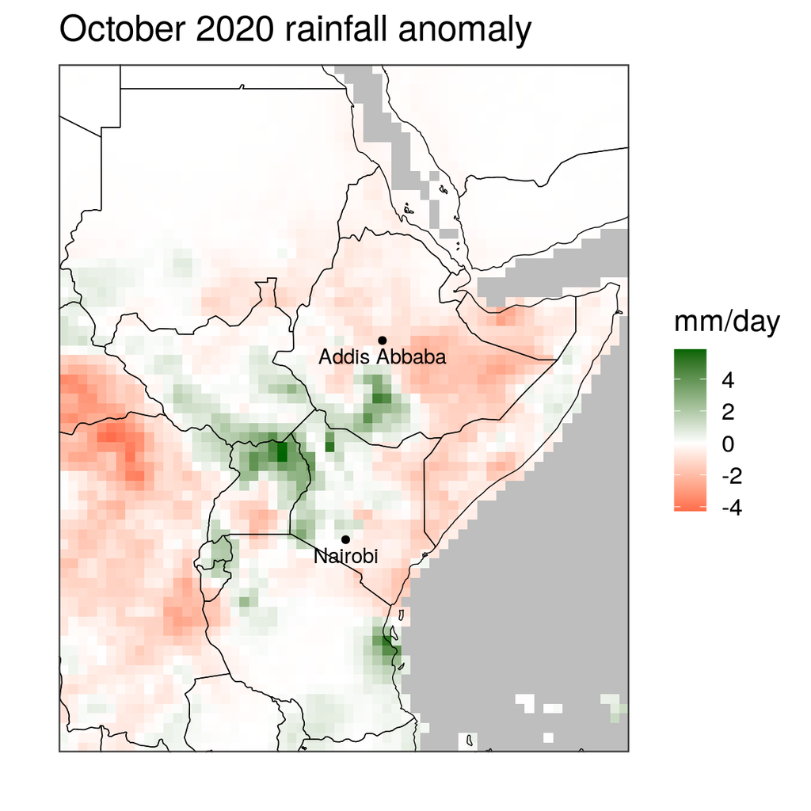

```r
pp = ggplot_dt(chirps_monthly[month == 10 & year == 2020], 'ano',
               mn = 'October 2020 rainfall anomaly',
               low = 'red', mid = 'white', high = 'darkgreen',
               midpoint = 0,
               name = 'mm/day') +
     geom_point(data = loc,mapping = aes(x = lon,y = lat)) +
     geom_text(data = loc,mapping = aes(x = lon,y = lat,label = name),vjust = 1.5)

print(pp)
```

Here, we added two layers to the original plot, the first one being the `geom_point`-layer that creates the two points and the second being the `geom_text`-layer that adds the labels of the points. `ggplot2` is a widely used package and there is a large variety of tutorials and books out there that can help you getting familiar with the syntax.

A frequently required operation is the changing of the font sizes of title and labels. The easiest way to do this is the command

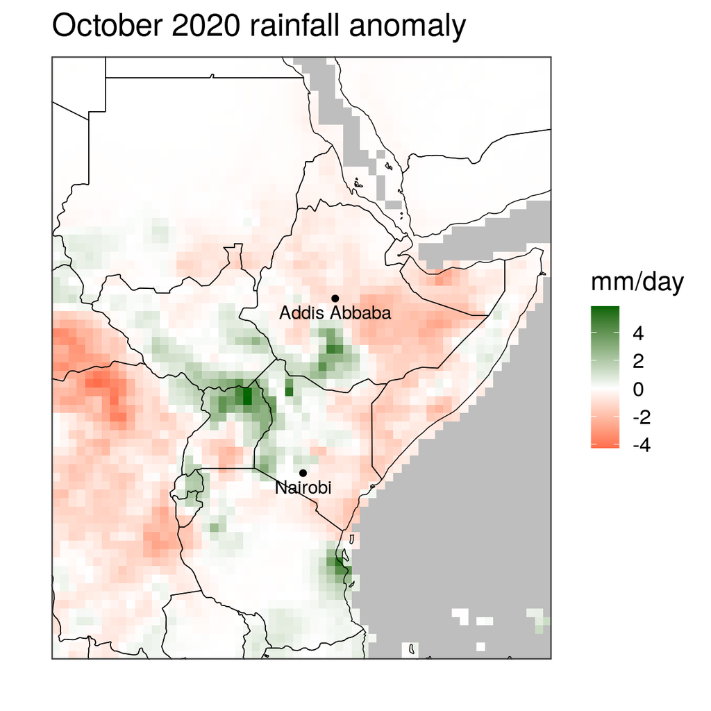

```r
theme_set(theme_bw(base_size = 16)) # defaults to 12
print(pp)
```

If we want to print the plot to an external file, all we have to do is

```r
pdf(file = '<path to file and filename>.pdf')
  print(pp)
dev.off()
```

This prints a .pdf file, but you can print .png and some other file formats similarly, see `?Devices` for an overview.

We can also use ggplots adding-layer-syntax to overwrite existing layers, for example if we want a fully customized colorscale:

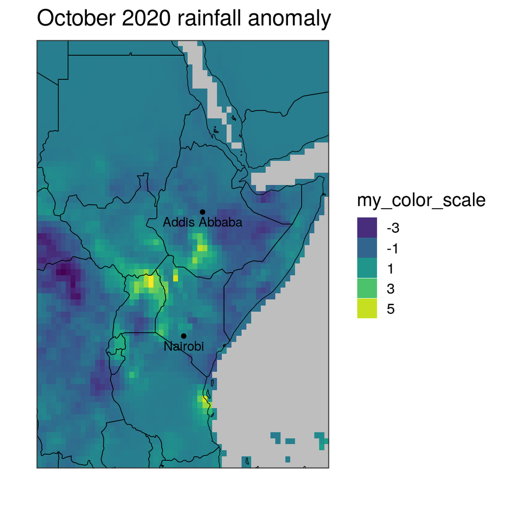

```r
library(viridis) # the viridis package contains some nice color scales
pp = pp + scale_fill_viridis(name = 'my_color_scale',breaks = seq(-5,5,by = 2),guide = 'legend')
print(pp)
```